# Project_Rus

2025-03-17

Проект в рамках курса “Анализ данных в социологии” НИУ ВШЭ СПБ 2025

В этом проекте требовалось провести анализ датасета European Social Survey для Великобритании (нужно было провести три статистических теста: ХИ-квадрат, Т-тест, Анализ дисперсий ANOVA) и написать их интерпретацию. Изначально проект был выполнен на английском языке, так как моя программа англоязычная. Данная версия на русском языке.

В этот раз мы будем анализировать восприятие здоровья в британском обществе. Мы будем использовать датасет ESS.

```r
library(tidyverse)
library(rstatix)
library(effsize)
library(psych)
library(car)
library(DescTools)
library(sjstats)
```

Сначала загрузим датасет, полученный с сайта ESS .

```r
ess <- read.csv('ESS11_subset.csv')
```

### Тест Хи-квадрат на независимость:

Мы предполагаем, что ответственность женщин за здоровье значительно превышает ответственность мужчин. Исследования подтверждают, что существуют различия в состоянии здоровья между мужчинами и женщинами, при этом женщины обычно проявляют большее чувство ответственности за свое здоровье и благополучие [2]. В контексте этого обсуждения “здоровье” определяется как состояние полного физического, психического и социального благополучия, а не просто отсутствие болезней, как это определено Всемирной организацией здравоохранения (ВОЗ) в ее Уставе [1]. Позже мы сосредоточимся на переменной субъективного благополучия, которая также относится к здоровью.

Согласно исследованиям, женщины чаще, чем мужчины, проявляют инициативу в предотвращении заболеваний и поддержании здорового образа жизни. Это может включать регулярные медицинские осмотры, скрининги и вакцинацию. Кроме того, женщины чаще следуют рекомендациям врачей и принимают лекарства [2].

### Сравнение переменных.

Исследовательский вопрос: Есть ли разница между ответами мужчин и женщин на субъективный уровень здоровья?

Нулевая гипотеза (H0): Нет статистически значимой разницы между полами в их субъективном благополучии. Альтернативная гипотеза (H1): Есть статистически значимая разница между полами в их субъективном благополучии.

```r
ess_health <- ess %>%
  select(gndr, health)
```

Теперь нам нужно оставить только значения, которые не являются пропущенными (NA) и не являются отказами. Мы проанализировали документацию, и ответы, которые нам нужны:

- для пола: 1 и 2, представляющие мужчин и женщин соответственно.
- для здоровья: от 1 до 5, представляющие следующие уровни: ‘Очень хорошее’, ‘Хорошее’, ‘Среднее’, ‘Плохое’, ‘Очень плохое’.

Создадим маски для фильтрации:

```r
h_cond = c(1:5) # для здоровья
g_cond = c(1,2) # для пола
```

Теперь отфильтруем данные, оставив только значения, которые мы указали выше.

```r
ess_health <- ess_health %>%
  filter(health %in% h_cond & gndr %in% g_cond)
```

Теперь проанализируем структуру данных.

```r
str(ess_health)
```

```
## 'data.frame':    40103 obs. of  2 variables:
##  $ gndr  : int  1 2 2 2 1 2 2 2 2 2 ...
##  $ health: int  3 2 1 3 2 1 2 2 2 2 ...
```

Значения числовые, поэтому нам нужно преобразовать их в категориальные переменные, чтобы выполнить тест Хи-квадрат.

Сделаем это с помощью следующих функций:

```r
ess_health$gndr <- as.factor(ess_health$gndr)
ess_health$health <- as.factor(ess_health$health)
```

Теперь структура данных следующая, однако интерпретировать результаты по кодам сложно.

```r
str(ess_health)
```

```
## 'data.frame':    40103 obs. of  2 variables:
##  $ gndr  : Factor w/ 2 levels "1","2": 1 2 2 2 1 2 2 2 2 2 ...
##  $ health: Factor w/ 5 levels "1","2","3","4",..: 3 2 1 3 2 1 2 2 2 2 ...
```

Переименуем уровни для переменной пола.

```r
levels(ess_health$gndr) <- c('Мужчина', 'Женщина')
```

Теперь для субъективного уровня здоровья.

```r
levels(ess_health$health) <- c('Очень хорошее', 'Хорошее', 'Среднее', 'Плохое', 'Очень плохое')
```

```r
cont_table <- table(ess_health)
```

```r
cont_table <- as.data.frame(cont_table)
```

Теперь визуализируем данные.

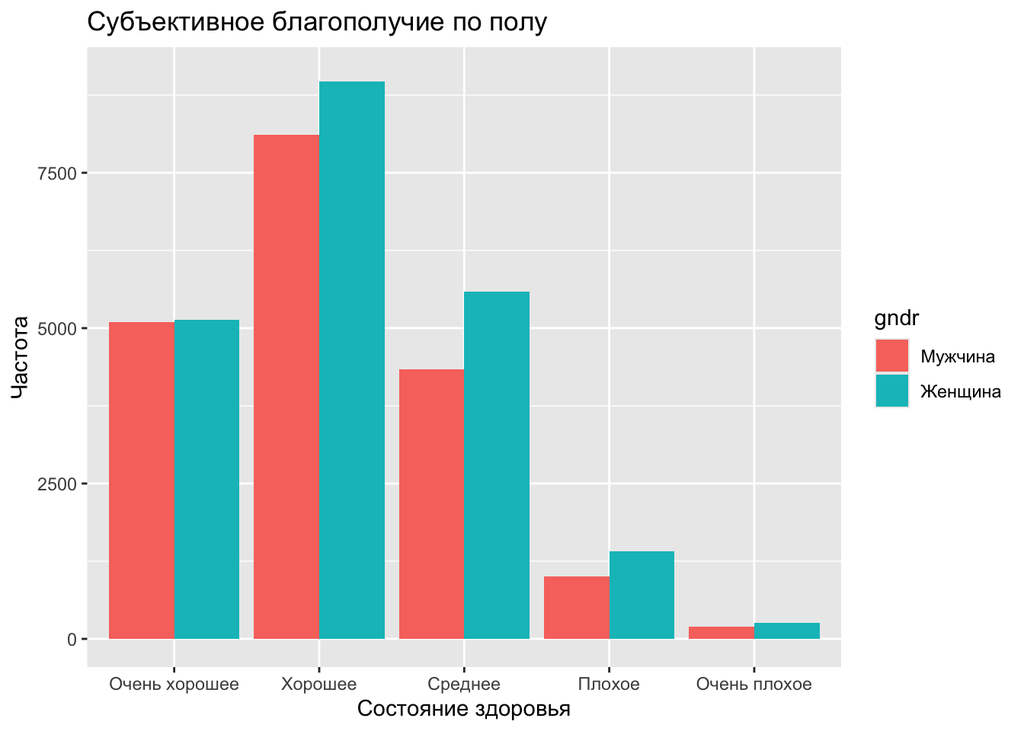

```r
ggplot(cont_table, aes(x = health, y = Freq, fill = gndr)) +
  geom_bar(stat = "identity", position = position_dodge()) +
  ylim(0, max(cont_table$Freq)+100)+
  labs(title = "Субъективное благополучие по полу",
       x = "Состояние здоровья",
       y = "Частота")
```

Данные показывают различия между полами. Видно, что больше женщин, чем мужчин, считают, что их здоровье плохое. Также видно, что больше женщин выбрали, что их здоровье воспринимается как среднее.

Перед проведением теста Хи-квадрат проверим, соблюдены ли необходимые для теста предположения.

Предположения взяты из лекционных слайдов (Ткачева, 2025).

Предположение 1: “Данные в ячейках должны быть частотами или подсчетами случаев, а не процентами или другими преобразованиями данных” (Ткачева, 2025). Это предположение соблюдено, так как данные показывают частоты разных категорий.

Предположение 2: “Уровни (или категории) переменных должны быть взаимоисключающими” (Ткачева, 2025). Это предположение соблюдено, так как категории взаимоисключающие.

Предположение 3: “Каждый субъект может вносить данные только в одну ячейку в χ2. Если, например, одни и те же субъекты тестируются с течением времени, так что сравнения проводятся для одних и тех же субъектов в момент времени 1, момент времени 2, момент времени 3 и т.д., то χ2 не может быть использован” (Ткачева, 2025). Это предположение соблюдено, так как данные представлены только в один момент времени, и каждый субъект действительно вносит данные только в одну ячейку.

Предположение 4: “Группы исследования должны быть независимыми” (Ткачева, 2025). Это предположение соблюдено, так как группы женщин и мужчин независимы, и они могли выбрать только один вариант в опросе.

Предположение 5: “Есть 2 переменные, и обе измеряются как категории, обычно на номинальном уровне” (Ткачева, 2025). Это предположение соблюдено, так как есть 2 переменные: пол (с 2 уровнями) и уровень субъективного благополучия (с 5 уровнями). Обе они являются категориальными переменными.

Предположение 6: “Ожидаемое значение ячейки должно быть 5 или более в 80% ячеек, и ни одна ячейка не должна иметь ожидаемое значение меньше одного.” Чтобы проверить это предположение, нам нужно запустить следующий код для проверки ожидаемых значений, однако это проверяется автоматически в R при запуске теста Хи-квадрат. Но мы проверим это с помощью кода.

```r
chisq.test(ess_health$gndr, ess_health$health)$expected
```

```
##                ess_health$health
## ess_health$gndr Очень хорошее  Хорошее  Среднее   Плохое Очень плохое
##         Мужчина       4779.17 7978.831 4638.084 1129.622     209.2931
##         Женщина       5450.83 9100.169 5289.916 1288.378     238.7069
```

Видно, что ожидаемые значения больше 5 во всех ячейках, что неудивительно, так как у нас большое количество наблюдений в датасете. Это означает, что предположение 6 соблюдено.

Теперь, после проверки всех предположений, можно запустить тест Хи-квадрат. Но сначала сформулируем гипотезы для теста.

Нулевая гипотеза (H0): Нет статистически значимой разницы между полами в их субъективном восприятии благополучия. Альтернативная гипотеза (H1): Есть статистически значимая разница между полами в их субъективном восприятии благополучия.

Теперь запустим тест Хи-квадрат на независимость для проверки гипотез.

```r
chisq.test(ess_health$gndr, ess_health$health)
```

```
##
##  Pearson's Chi-squared test
##
## data:  ess_health$gndr and ess_health$health
## X-squared = 107.79, df = 4, p-value < 2.2e-16
```

Нулевая гипотеза может быть отвергнута. Альтернативная гипотеза может быть принята. Это означает, что есть статистически значимая разница между полами в их субъективном восприятии благополучия, что означает, что мужчины и женщины воспринимают свое здоровье по-разному.

Чтобы понять различия между группами, проанализируем стандартизированные остатки.

```r
round(chisq.test(ess_health$gndr, ess_health$health)$stdres, 2)
```

```
##                ess_health$health
## ess_health$gndr Очень хорошее Хорошее Среднее Плохое Очень плохое
##         Мужчина          7.18    2.66   -7.01  -5.20        -1.74
##         Женщина         -7.18   -2.66    7.01   5.20         1.74
```

Интерпретация результатов:

Для мужчин: - Очень хорошее: 7.18 (значительно выше ожидаемого) - Хорошее: 2.66 (умеренно выше ожидаемого) - Среднее: -7.01 (значительно ниже ожидаемого) - Плохое: -5.20 (значительно ниже ожидаемого) - Очень плохое: -1.74 (незначительно)

Для женщин: - Очень хорошее: -7.18 (значительно ниже ожидаемого) - Хорошее: -2.66 (умеренно ниже ожидаемого) - Среднее: 7.01 (значительно выше ожидаемого) - Плохое: 5.20 (значительно выше ожидаемого) - Очень плохое: 1.74 (незначительно)

Выводы: - Мужчины чаще сообщают о “Очень хорошем” и “Хорошем” здоровье, чем ожидалось, в то время как они реже сообщают о “Среднем”, “Плохом” и “Очень плохом” здоровье. - Женщины чаще сообщают о “Среднем” и “Плохом” здоровье, чем ожидалось, в то время как они реже сообщают о “Очень хорошем” и “Хорошем” здоровье.

Возможная интерпретация: Таким образом, можно увидеть, что женщины оценивают свое здоровье ниже, чем мужчины. Это можно интерпретировать через идею, что женщины больше внимания уделяют своему здоровью, что означает, что они более осведомлены о своих проблемах со здоровьем. В то время как мужчины склонны меньше обращать внимание на свое здоровье, что означает, что они менее осведомлены о своем состоянии здоровья, что приводит к тому, что они сообщают о более высоких уровнях здоровья [2]. Это похоже на то, что было упомянуто в начале нашего обсуждения здоровья и пола в контексте британского общества.

### Т-тест

Субъективное благополучие (СБ) — это конструкт, который относится к тому, как люди оценивают свою жизнь, включая как когнитивные, так и аффективные компоненты. Когнитивные оценки включают удовлетворенность жизнью, а аффективные компоненты включают наличие положительных эмоций и отсутствие отрицательных эмоций [3].

Исследования последовательно показывают, что СБ связано с различными результатами, включая физическое здоровье, продуктивность и социальные отношения [4]. Например, люди с более высоким СБ, как правило, демонстрируют лучшие механизмы совладания, более сильную иммунную систему и большую продолжительность жизни [5]. Напротив, низкое СБ связано с психическими расстройствами, такими как депрессия и тревога, а также с худшими физическими результатами здоровья [6].

Мы собираемся выяснить, есть ли разница между средними значениями групп с хорошим субъективным благополучием и плохим субъективным благополучием с точки зрения их удовлетворенности жизнью.

Исследовательский вопрос: Есть ли значительная разница в удовлетворенности жизнью между людьми с хорошим субъективным благополучием и теми, у кого оно плохое?

Нулевая гипотеза H0: Нет разницы между средними значениями групп с хорошим субъективным благополучием и плохим субъективным благополучием. Альтернативная гипотеза H1: Есть разница между средними значениями групп с хорошим субъективным благополучием и плохим субъективным благополучием.

Фильтрация данных:

Сначала данные нужно отфильтровать. Сейчас есть пропущенные значения (NA) и данные, которые не несут никакой информации. Кроме того, нам нужно будет преобразовать переменную здоровья в бинарную категориальную.

```r
ess_lifesfct <- ess %>%
  select(stflife, health)
```

Теперь создадим маски для фильтрации данных. Мы будем использовать то же условие для здоровья (использованное в тесте Хи-квадрат), чтобы избавиться от пропущенных данных. Нам нужно создать маску для условия только для удовлетворенности жизнью.

```r
stf_cond <- c(0:10)
```

```r
ess_lifesfct <- ess_lifesfct %>%
  filter(health %in% h_cond & stflife %in% stf_cond)
```

Теперь, чтобы выполнить Т-тест, мы создадим две группы на основе субъективного благополучия (переменная здоровья). Чтобы проанализировать средние значения удовлетворенности жизнью.

```r
ess_lifesfct$health <- as.factor(ess_lifesfct$health)
```

```r
levels(ess_lifesfct$health)
```

```
## [1] "1" "2" "3" "4" "5"
```

```r
table(ess_lifesfct$health)
```

```
##
##     1     2     3     4     5
## 10159 16960  9858  2395   442
```

Мы удалим категорию “Среднее”, так как нам нужны две группы с хорошим и плохим здоровьем, чтобы иметь возможность выполнить Т-тест, который требует две группы и одну числовую переменную.

```r
ess_lifesfct <- ess_lifesfct %>%
  filter(health != "3")
```

```r
table(ess_lifesfct$health)
```

```
##
##     1     2     3     4     5
## 10159 16960     0  2395   442
```

```r
ess_lifesfct$health <- droplevels(ess_lifesfct$health)
```

```r
table(ess_lifesfct$health)
```

```
##
##     1     2     4     5
## 10159 16960  2395   442
```

```r
levels(ess_lifesfct$health) <- c("Хорошее", "Хорошее", "Плохое", "Плохое")
```

Теперь мы отфильтровали данные. Теперь у нас есть переменная здоровья с двумя категориями: хорошее и плохое. Также у нас есть вторая переменная — уровень удовлетворенности жизнью, который является интервальным с значениями от 0 до 10, где 0 — это самая низкая удовлетворенность жизнью, а 10 — самая высокая.

```r
str(ess_lifesfct)
```

```
## 'data.frame':    29956 obs. of  2 variables:
##  $ stflife: int  9 10 9 8 8 8 8 8 8 5 ...
##  $ health : Factor w/ 2 levels "Хорошее","Плохое": 1 1 1 1 1 1 1 1 1 1 ...
```

```r
table(ess_lifesfct)
```

```
##        health
## stflife Хорошее Плохое
##      0      116    118
##      1       97     69
##      2      257    177
##      3      521    242
##      4      700    248
##      5     1852    544
##      6     2111    332
##      7     5016    383
##      8     8284    395
##      9     5096    162
##      10    3069    167
```

Теперь мы отфильтровали данные, чтобы их можно было использовать для дальнейшего анализа.

1. Визуализируем данные с помощью диаграмм размаха (boxplot).

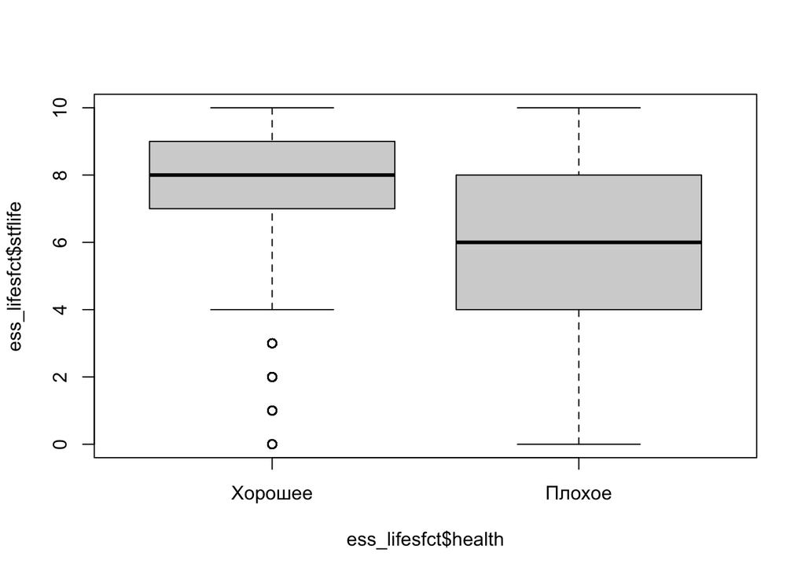

```r
boxplot(ess_lifesfct$stflife ~ ess_lifesfct$health)
```

Диаграммы размаха показывают, что люди с хорошим субъективным благополучием сообщают о более высоких уровнях удовлетворенности жизнью, чем люди с плохим субъективным благополучием.

Для выполнения Т-теста или выбора непараметрического теста Уилкоксона нам нужно проверить, соблюдены ли предположения для Т-теста.

Предположение 1: Независимость наблюдений (соблюдено, так как наблюдения независимы). Предположение 2: Данные должны быть нормально распределены (будет проверено). Предположение 3: Однородность дисперсий (будет проверено).

Предположение 2: Проверим, нормально ли распределены данные.

Посмотрим на описательную статистику.

```r
describeBy(ess_lifesfct, group = ess_lifesfct$health)
```

```
##
##  Descriptive statistics by group
## group: Хорошее
##         vars     n mean  sd median trimmed  mad min max range  skew kurtosis
## stflife    1 27119 7.55 1.8      8    7.73 1.48   0  10    10 -1.14     1.79
## health     2 27119 1.00 0.0      1    1.00 0.00   1   1     0   NaN      NaN
##           se
## stflife 0.01
## health  0.00
## ------------------------------------------------------------
## group: Плохое
##         vars    n mean   sd median trimmed  mad min max range  skew kurtosis
## stflife    1 2837 5.58 2.53      6    5.66 2.97   0  10    10 -0.28    -0.52
## health     2 2837 2.00 0.00      2    2.00 0.00   2   2     0   NaN      NaN
##           se
## stflife 0.05
## health  0.00
```

Результаты для хорошего здоровья: - Среднее: 7.55 - Медиана: 8 - Стандартное отклонение: 1.8 - Асимметрия: -1.14 (левостороннее распределение) - Эксцесс: 1.79 (более тяжелые хвосты, чем у нормального распределения)

Результаты для плохого здоровья: - Среднее: 5.58 - Медиана: 6 - Стандартное отклонение: 2.53 - Асимметрия: -0.28 (слегка левостороннее распределение) - Эксцесс: -0.52 (более легкие хвосты, чем у нормального распределения)

Интерпретация: - Группа с хорошим субъективным благополучием имеет более высокое среднее и медианное значение удовлетворенности жизнью по сравнению с группой с плохим субъективным благополучием. - Стандартное отклонение больше в группе с плохим здоровьем, что указывает на большую изменчивость в уровнях удовлетворенности жизнью. - Обе группы демонстрируют левостороннее распределение, но асимметрия более выражена в группе с хорошим здоровьем.

```r
good_health <- ess_lifesfct$stflife[ess_lifesfct$health == "Хорошее"]
```

```r
poor_health <- ess_lifesfct$stflife[ess_lifesfct$health == "Плохое"]
```

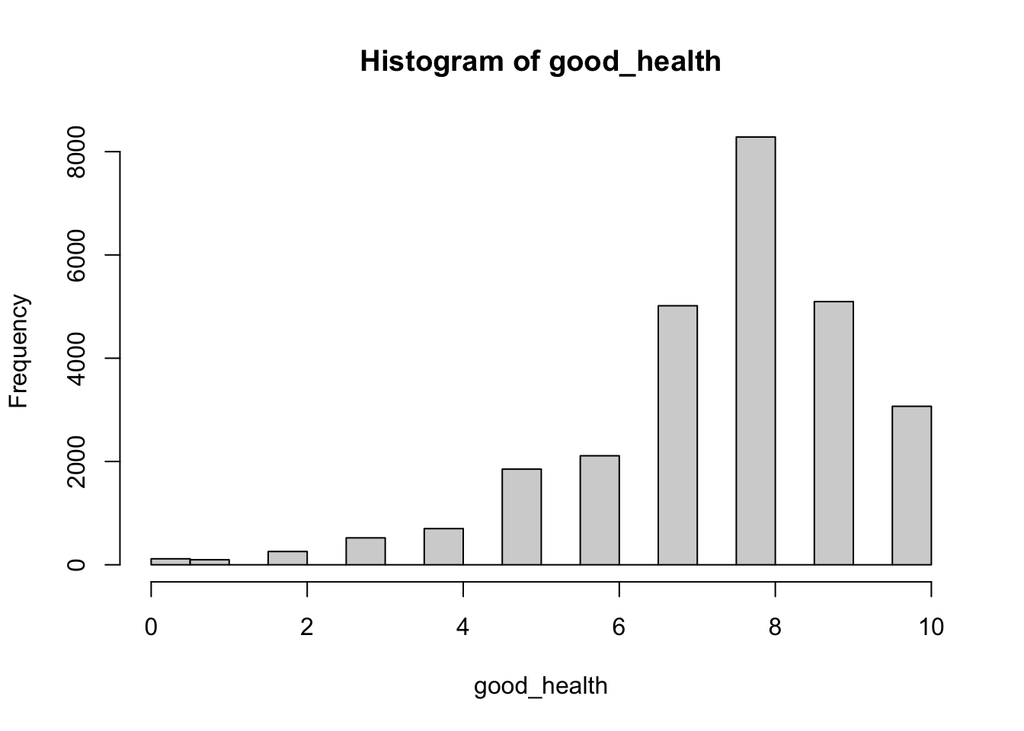

```r
hist(good_health)
```

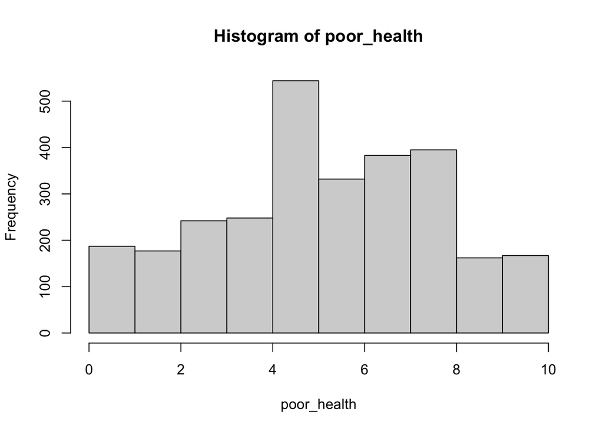

```r
hist(poor_health)
```

Гистограммы показывают, что данные не являются нормальными.

```r
shapiro.test(poor_health)
```

```
##
##  Shapiro-Wilk normality test
##
## data:  poor_health
## W = 0.96568, p-value < 2.2e-16
```

Тест показывает, что распределение не является нормальным.

```r
ks.test(good_health, pnorm)
```

```
##
##  Asymptotic one-sample Kolmogorov-Smirnov test
##
## data:  good_health
## D = 0.98132, p-value < 2.2e-16
## alternative hypothesis: two-sided
```

Распределение не является нормальным, так как p-значение меньше 0.05.

Поэтому мы выберем непараметрический тест.

Предположение 2 не соблюдено. Данные не являются нормальными, поэтому мы выберем непараметрический тест.

Предположение 3. Проверим однородность дисперсий.

```r
leveneTest(stflife ~ health, data = ess_lifesfct)
```

```
## Levene's Test for Homogeneity of Variance (center = median)
##          Df F value    Pr(>F)
## group     1  859.91 < 2.2e-16 ***
##       29954
## ---
## Signif. codes:  0 '***' 0.001 '**' 0.01 '*' 0.05 '.' 0.1 ' ' 1
```

Дисперсии не равны, поэтому мы будем использовать непараметрический тест.

Предположение 3 не соблюдено, поэтому мы выбираем непараметрический тест.

Запустим непараметрический тест Уилкоксона.

```r
wilcox.test(ess_lifesfct$stflife ~ ess_lifesfct$health)
```

```
##
##  Wilcoxon rank sum test with continuity correction
##
## data:  ess_lifesfct$stflife by ess_lifesfct$health
## W = 56665542, p-value < 2.2e-16
## alternative hypothesis: true location shift is not equal to 0
```

P-значение меньше 0.05, что указывает на статистически значимую разницу в распределениях удовлетворенности жизнью между двумя группами. Таким образом, нулевая гипотеза может быть отвергнута.

Теперь рассчитаем размер эффекта.

```r
rstatix::wilcox_effsize(stflife ~ health, data = ess_lifesfct)
```

```
## # A tibble: 1 × 7
##   .y.     group1  group2 effsize    n1    n2 magnitude
## * <chr>   <chr>   <chr>    <dbl> <int> <int> <ord>
## 1 stflife Хорошее Плохое   0.245 27119  2837 small
```

Тест Уилкоксона подтверждает значительную разницу в удовлетворенности жизнью между двумя группами. Размер эффекта небольшой, что говорит о том, что хотя разница статистически значима, она может быть не очень большой на практике.

Хотя мы провели непараметрический тест, полезно взглянуть на результаты параметрического Т-теста, чтобы увидеть различия в средних значениях. Для сравнения средних значений двух групп мы провели Т-тест Уэлча, который не предполагает равенства дисперсий между группами.

```r
t.test(stflife ~ health, data = ess_lifesfct, var.equal = F)
```

```
##
##  Welch Two Sample t-test
##
## data:  stflife by health
## t = 40.6, df = 3143.8, p-value < 2.2e-16
## alternative hypothesis: true difference in means between group Хорошее and group Плохое is not equal to 0
## 95 percent confidence interval:
##  1.880841 2.071727
## sample estimates:
## mean in group Хорошее  mean in group Плохое
##              7.553302              5.577018
```

Видно, что среднее значение удовлетворенности жизнью выше для группы с хорошим субъективным благополучием.

Интерпретация: - Результаты Т-теста указывают на статистически значимую разницу в средних значениях удовлетворенности жизнью между двумя группами (p < 0.05). - 95% доверительный интервал для разницы средних не включает ноль, что дополнительно подтверждает отвержение нулевой гипотезы. - Среднее значение удовлетворенности жизнью для группы с хорошим здоровьем значительно выше, чем для группы с плохим здоровьем.

Выводы: - Как непараметрический тест Уилкоксона, так и параметрический Т-тест Уэлча указывают на статистически значимую разницу в удовлетворенности жизнью между людьми с хорошим и плохим субъективным благополучием. - Размер эффекта небольшой, что говорит о том, что хотя разница статистически значима, она может быть не очень большой на практике. - Нулевая гипотеза отвергается, и мы заключаем, что есть значительная разница в удовлетворенности жизнью между двумя группами.

Возможная интерпретация. Значительная разница между средними значениями групп с хорошим и плохим субъективным благополучием (СБ) предполагает, что СБ — это значимый конструкт с различными психологическими и поведенческими результатами. Это согласуется с теорией Диннера (1984), что СБ отражает общую оценку человеком своей жизни, что может влиять на здоровье, продуктивность и социальное функционирование. Более высокое СБ может указывать на лучшие механизмы совладания и устойчивость, что подтверждается Любомирски и др. (2005).

### Дисперсионный анализ (ANOVA)

Исследования последовательно показывают, что физическая активность, особенно спорт, положительно связана с субъективным благополучием (СБ) [7]. Регулярная физическая активность связана с улучшением психического здоровья, снижением стресса и улучшением эмоционального благополучия [8]. Однако связь между частотой занятий спортом и различными уровнями СБ остается недостаточно изученной, особенно в больших и разнообразных популяциях.

Исследовательский вопрос: Есть ли статистически значимая разница в средних значениях еженедельной спортивной активности среди людей с разными уровнями субъективного благополучия (СБ)?

Гипотезы: Нулевая гипотеза (H0): Нет статистически значимой разницы между средними значениями еженедельной спортивной активности среди разных групп СБ. Альтернативная гипотеза (H1): Есть статистически значимая разница между средними значениями еженедельной спортивной активности среди разных групп СБ.

Сначала отфильтруем данные, чтобы их можно было использовать для дальнейшего анализа.

```r
ess_health_sport <- ess %>%
  select(health, dosprt)
```

```r
ess_health_sport <- ess_health_sport %>%
  filter((health %in% h_cond) & !(dosprt %in% c(77, 88, 99)))
```

```r
ess_health_sport$health <- as.factor(ess_health_sport$health)
```

```r
levels(ess_health_sport$health) <- c('Очень хорошее', 'Хорошее', 'Среднее', 'Плохое', 'Очень плохое')
```

```r
table(ess_health_sport)
```

```
##                dosprt
## health             0    1    2    3    4    5    6    7
##   Очень хорошее 1452  565 1234 1583 1230 1193  508 2415
##   Хорошее       3277 1377 2355 2414 1566 1543  633 3723
##   Среднее       3316  787 1159  986  628  694  268 1944
##   Плохое        1311  185  161  150   69  111   43  351
##   Очень плохое   312   17   20   16   11   15    4   45
```

Визуализируем данные с помощью диаграмм размаха.

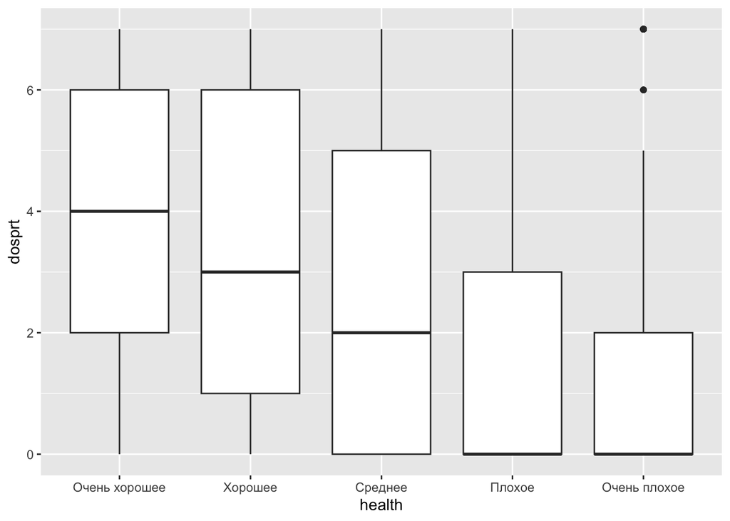

```r
ggplot(data = ess_health_sport, aes(x = health, y = dosprt))+
  geom_boxplot()
```

Из диаграмм размаха видно, что возможна разница между средними значениями. Кажется, что люди с лучшим субъективным благополучием чаще занимаются спортом в течение недели.

Теперь проверим предположения для теста ANOVA.

Предположение 1. Независимость: Наблюдения должны быть независимы друг от друга. Данные независимы, так как каждое наблюдение — это уникальный человек (Предположение 1 соблюдено).

Предположение 2. Однородность дисперсий (будет проверено).

Предположение 3. Нормальность остатков (будет проверено).

Проверим однородность дисперсий.

```r
leveneTest(ess_health_sport$dosprt ~ ess_health_sport$health)
```

```
## Levene's Test for Homogeneity of Variance (center = median)
##          Df F value    Pr(>F)
## group     4  86.103 < 2.2e-16 ***
##       39666
## ---
## Signif. codes:  0 '***' 0.001 '**' 0.01 '*' 0.05 '.' 0.1 ' ' 1
```

Дисперсии не равны, мы проведем однофакторный дисперсионный анализ с учетом этого.

```r
oneway.test(ess_health_sport$dosprt ~ ess_health_sport$health, var.equal = F)
```

```
##
##  One-way analysis of means (not assuming equal variances)
##
## data:  ess_health_sport$dosprt and ess_health_sport$health
## F = 451.35, num df = 4, denom df = 2935, p-value < 2.2e-16
```

P-значение говорит нам, что есть статистически значимая разница между средними значениями групп. Это означает, что мы можем отвергнуть нулевую гипотезу H0.

Теперь проверим нормальность остатков для выполнения пост-хок тестов.

Предположение 3. Нормальность остатков.

```r
one.way.test <- aov(ess_health_sport$dosprt ~ ess_health_sport$health)
```

```r
summary(one.way.test)
```

```
##                            Df Sum Sq Mean Sq F value Pr(>F)
## ess_health_sport$health     4  11503  2875.8   444.6 <2e-16 ***
## Residuals               39666 256554     6.5
## ---
## Signif. codes:  0 '***' 0.001 '**' 0.01 '*' 0.05 '.' 0.1 ' ' 1
```

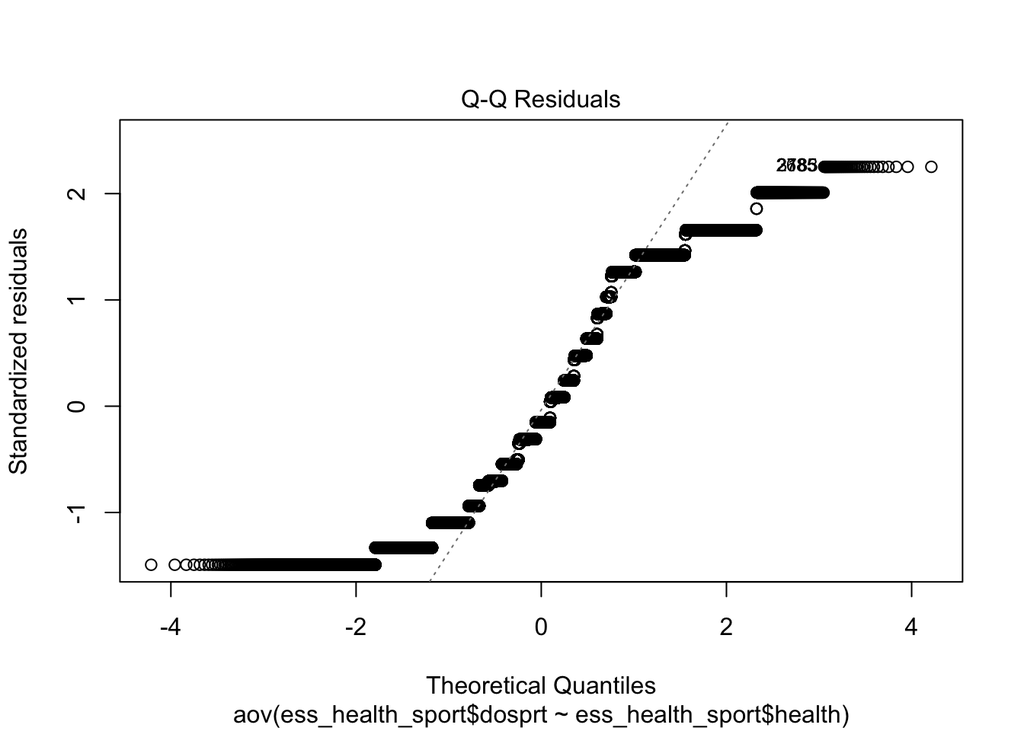

```r
plot(one.way.test, 2)
```

Из графика QQ-plot видно, что остатки не совсем нормальные.

Теперь проведем тест Колмогорова-Смирнова на нормальность.

```r
anova.res <- residuals(object = one.way.test)
```

```r
ks.test(anova.res, pnorm)
```

```
##
##  Asymptotic one-sample Kolmogorov-Smirnov test
##
## data:  anova.res
## D = 0.31208, p-value < 2.2e-16
## alternative hypothesis: two-sided
```

Остатки не являются нормальными.

Но также посмотрим на гистограмму.

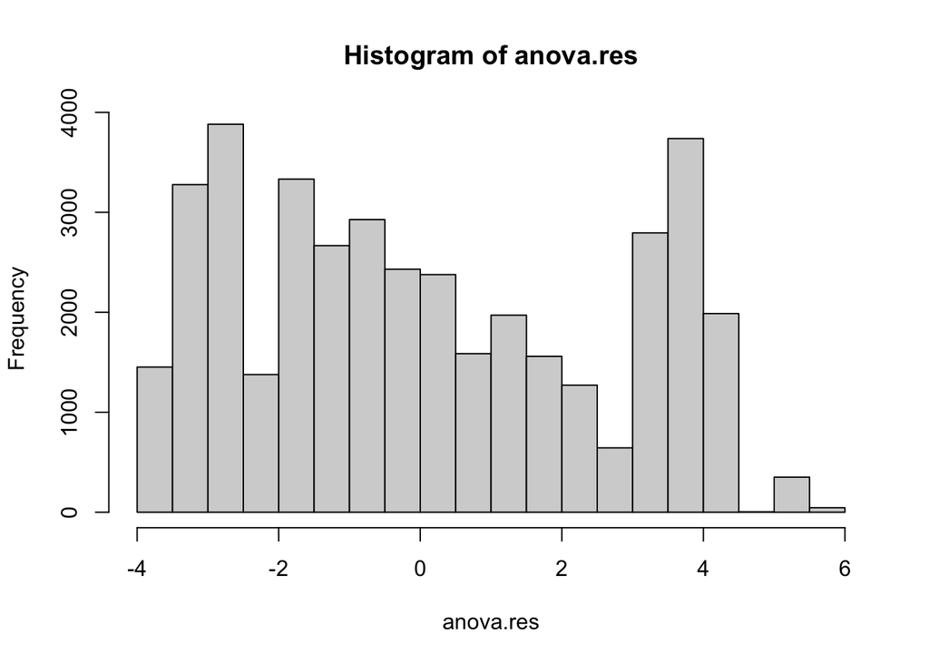

```r
hist(anova.res)
```

Остатки не являются нормальными, судя по гистограмме.

### Пост-хок тест

```r
pairwise.t.test(ess_health_sport$dosprt, ess_health_sport$health,
                adjust = "bonferroni", pool.sd = T)
```

```
##
##  Pairwise comparisons using t tests with pooled SD
##
## data:  ess_health_sport$dosprt and ess_health_sport$health
##
##              Очень хорошее Хорошее Среднее Плохое
## Хорошее      < 2e-16       -       -       -
## Среднее      < 2e-16       < 2e-16 -       -
## Плохое       < 2e-16       < 2e-16 < 2e-16 -
## Очень плохое < 2e-16       < 2e-16 < 2e-16 3.6e-06
##
## P value adjustment method: holm
```

Попарные сравнения показывают, что все пары групп СБ имеют статистически значимые различия в средних значениях еженедельной спортивной активности (p < 0.05 после поправки). P-значения крайне малы (< 2e-16 для большинства сравнений), что указывает на очень сильные доказательства против нулевой гипотезы для каждой пары. Единственное сравнение с немного более высоким p-значением — между группами “Плохое” и “Очень плохое” (p = 3.6e-06), но оно все еще очень значимо.

Теперь перепроверим анализ с помощью непараметрического теста.

```r
kruskal.test(ess_health_sport$dosprt ~ ess_health_sport$health)
```

```
##
##  Kruskal-Wallis rank sum test
##
## data:  ess_health_sport$dosprt by ess_health_sport$health
## Kruskal-Wallis chi-squared = 1949.9, df = 4, p-value < 2.2e-16
```

Видно, что непараметрический тест показывает, что есть статистически значимая разница между рангами средних значений. Таким образом, мы все еще можем отвергнуть нулевую гипотезу.

Теперь проведем непараметрический пост-хок тест.

```r
DunnTest(ess_health_sport$dosprt ~ ess_health_sport$health)
```

```
##
##  Dunn's test of multiple comparisons using rank sums : holm
##
##                            mean.rank.diff   pval
## Хорошее-Очень хорошее           -1820.674 <2e-16 ***
## Среднее-Очень хорошее           -4639.759 <2e-16 ***
## Плохое-Очень хорошее            -8816.754 <2e-16 ***
## Очень плохое-Очень хорошее     -11675.125 <2e-16 ***
## Среднее-Хорошее                 -2819.085 <2e-16 ***
## Плохое-Хорошее                  -6996.080 <2e-16 ***
## Очень плохое-Хорошее            -9854.451 <2e-16 ***
## Плохое-Среднее                  -4176.995 <2e-16 ***
## Очень плохое-Среднее            -7035.366 <2e-16 ***
## Очень плохое-Плохое             -2858.371  1e-06 ***
## ---
## Signif. codes:  0 '***' 0.001 '**' 0.01 '*' 0.05 '.' 0.1 ' ' 1
```

Все попарные сравнения между группами субъективного благополучия (СБ) статистически значимы (p < 0.05 после поправки). Это указывает на то, что есть значительные различия в распределении еженедельной спортивной активности на всех уровнях СБ.

Различия в средних рангах отрицательны для всех сравнений, что указывает на то, что люди с более низким СБ (например, “Среднее”, “Плохое”, “Очень плохое”) склонны иметь более низкие ранги еженедельной спортивной активности по сравнению с теми, у кого более высокое СБ (например, “Очень хорошее”, “Хорошее”).

Это предполагает, что люди с более низким субъективным благополучием менее склонны заниматься регулярной спортивной активностью.

### Размер эффекта

Теперь рассчитаем размер эффекта.

```r
anova_stats(one.way.test)
```

```
## etasq | partial.etasq | omegasq | partial.omegasq | epsilonsq | cohens.f
## ------------------------------------------------------------------------
## 0.043 |         0.043 |   0.043 |           0.043 |     0.043 |    0.212
##       |               |         |                 |           |
##
## etasq |                    term |     sumsq |    df |   meansq | statistic
## --------------------------------------------------------------------------
## 0.043 | ess_health_sport$health | 11503.379 |     4 | 2875.845 |   444.637
##       |               Residuals | 2.566e+05 | 39666 |    6.468 |
##
## etasq | p.value | power
## -----------------------
## 0.043 |  < .001 |     1
##       |         |
```

Хотя результаты ANOVA статистически значимы, размер эффекта (etasq 0.043) предполагает, что практическая значимость связи между субъективным благополучием и еженедельной спортивной активностью небольшая. Это означает, что хотя субъективное благополучие объясняет статистически значимую часть дисперсии спортивной активности, величина этой связи небольшая

```r
kruskal_effsize(ess_health_sport, dosprt ~ health)
```

```
## # A tibble: 1 × 5
##   .y.        n effsize method  magnitude
## * <chr>  <int>   <dbl> <chr>   <ord>
## 1 dosprt 39671  0.0491 eta2[H] small
```

Непараметрический эффект также мал, что подтверждает, что связь слабая между группами.

Интерпретация: - Более высокое субъективное благополучие (СБ) связано с более высокими уровнями еженедельной спортивной активности. Например: - Люди, которые сообщают о “Очень хорошем” здоровье, занимаются спортом значительно чаще, чем те, кто сообщает о “Хорошем”, “Среднем”, “Плохом” или “Очень плохом” здоровье. - Аналогично, люди с “Хорошим” здоровьем занимаются спортом чаще, чем те, у кого “Среднее”, “Плохое” или “Очень плохое” здоровье.

Выводы для ANOVA: Таким образом, мы можем отклонить нулевую гипотезу. Анализ демонстрирует статистически значимую связь между субъективным благополучием и еженедельной спортивной активностью, причем люди с более высоким благополучием занимаются спортом чаще. Однако небольшой размер эффекта указывает на то, что субъективное благополучие объясняет только небольшую часть дисперсии спортивной активности.

### Ссылки

1 - https://www.who.int/about/governance/constitution

2- https://www.researchgate.net/profile/Johan-Ormel/publication/11626485_Chronic_disease_in_elderly_couples_are_women_more_responsive_to_their_spouses%27_health_condition_than_men/links/5b62f9ad0f7e9bc79a75dd13/Chronic-disease-in-elderly-couples-are-women-more-responsive-to-their-spouses-health-condition-than-men.pdf

3- Diener, E. (1984). Subjective well-being. Psychological Bulletin, 95(3), 542-575. https://doi.org/10.1037/0033-2909.95.3.542 [Полный текст доступен по ссылке: https://www.researchgate.net/publication/232469575_Subjective_Well-Being]

4- Lyubomirsky, S., King, L., & Diener, E. (2005). The benefits of frequent positive affect: Does happiness lead to success? Psychological Bulletin, 131(6), 803-855. https://doi.org/10.1037/0033-2909.131.6.803 [Полный текст доступен по ссылке: https://www.researchgate.net/publication/232514632_The_Benefits_of_Frequent_Positive_Affect_Does_Happiness_Lead_to_Success]

5 - Steptoe, A., Deaton, A., & Stone, A. A. (2015). Subjective wellbeing, health, and ageing. The Lancet, 385(9968), 640-648. https://doi.org/10.1016/S0140-6736(13)61489-0 [Полный текст доступен по ссылке: https://www.thelancet.com/journals/lancet/article/PIIS0140-6736(13)61489-0/fulltext]

6 - Keyes, C. L. M. (2005). Mental illness and/or mental health? Investigating axioms of the complete state model of health. Journal of Consulting and Clinical Psychology, 73(3), 539-548. https://doi.org/10.1037/0022-006X.73.3.539 [Полный текст доступен по ссылке: https://www.researchgate.net/publication/7665504_Mental_Illness_andor_Mental_Health_Investigating_Axioms_of_the_Complete_State_Model_of_Health]

7 - Penedo, F. J., & Dahn, J. R. (2005). Exercise and well-being: A review of mental and physical health benefits associated with physical activity. Current Opinion in Psychiatry, 18(2), 189–193. https://doi.org/10.1097/00001504-200503000-00013

8 - Warburton, D. E. R., Nicol, C. W., & Bredin, S. S. D. (2006). Health benefits of physical activity: The evidence. Canadian Medical Association Journal, 174(6), 801–809. https://doi.org/10.1503/cmaj.051351 ```